# Emendas parlamentares repassadas aos estados nordestinos

12 de agosto de 2016

# Variáveis escolhidas

As observações/convênios foram filtrados para considerar apenas os estados nordestinos. Além disso, a fim de restringir mais a quantidade de dados, foram filtrados aquele convênios cuja função imputada está na área de urbanismo. Saúde e Urbanismo são as duas áreas onde mais repasses de emendas parlamentares são feitos. Valores maiores são repassados para Saúde, porém mais cidades são contempladas com emendas para segunda opção, o que motivou minha escolha por ela.

O objetivo aqui é comparar os repasses de emendas por parte do governo federal para uma determinada cidade em dois anos diferentes. Assim, foram selecionados os anos de 2014 e 2015 (Como 2016 ainda não acabou, talvez não pudéssemos tirar conclusões muito convincentes). Foi feito uma agrupamento por cidade para assim obtermos o valor total repassado para elas com a função citada acima (Urbanismo).

Os valores foram transformados em log para uma melhor visualização.

# 1. Método de agrupamento utilizado

Aglomeração hierárquica usando o método Ward (e o método euclidiano para medir a distância entre os pontos). O motivo da escolha foi ter apresentado um resultado melhor que o método K-Means.

# 2. Parâmetros

A quantidade de grupos desejada para o agrupamento ficou entre 3 e 4, pois apresentaram resultados mais satisfatórios. O método para distância entre os pontos foi o “euclidean” e o método para distância entre os grupos foi o “Ward.D”

# 3. Qualidade do agrupamento

O primeiro gráfico mostrou um agrupamento preciso, e até lógico. Nas análises posteriores, julgo os agrupamentos como razoáveis. Alguns pontos estão bem próximos uns dos outros, mas em grupos diferentes. O gráfico de silhueta mostrou que alguns não se relacionam tão bem com o grupo ao qual foi incluído.

# 4. Conclusões

Serão abordadas à medida que os gráficos forem apresentados

Aqui as cidades foram agrupadas em 3 grupos bem claros. As que receberam repasse apenas em 2014, as que receberam apenas em 2015 e as que receberam repasse em ambos os anos. Lembrando que são levadas em consideração apenas os convênios cuja função imputada é Urbanismo.

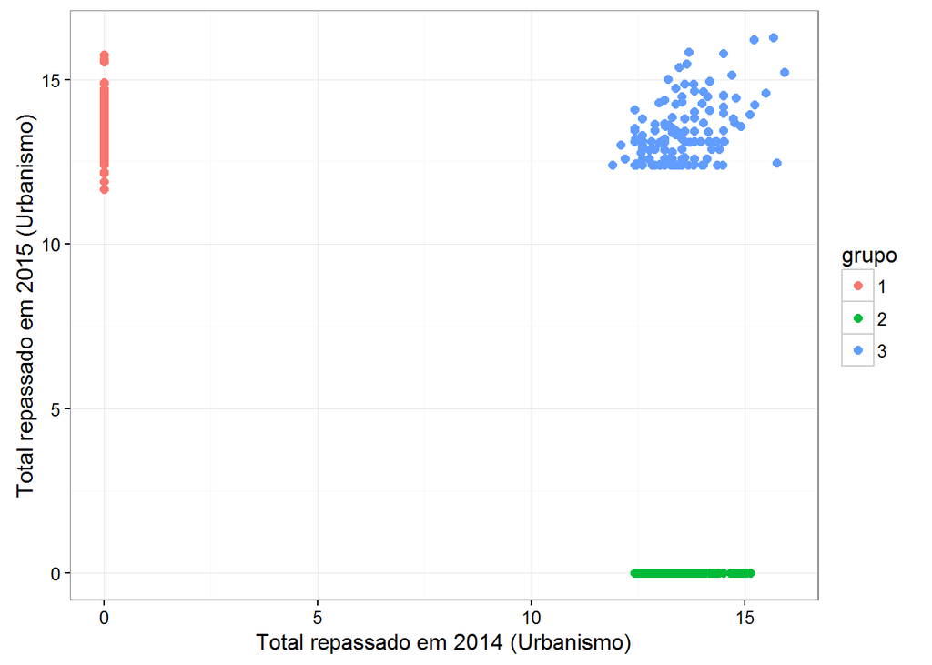

Agora vamos considerar apenas as cidades que receberam repasse nos dois anos e observar como se comporta um agrupamento em 3 grupos.

Conforme esperado, muitas das capitais figuram no grupo azul, a exemplo de Fortaleza, Maceió, Teresina, Salvador, Recife e Aracaju. Da Paraíba, Campina Grande e Guarabira estão presentes. João Pessa recebeu muitos repasses na área de saúde, mas nenhuma de Urbanismo nesses dois anos. Natal e São Luís não aparecem nesse agrupamento pois não possuem repasses recebidos registrados em 2014, apenas em 2015.

Outro ponto interessante observado é que das 36 cidades do grupo azul, 12 são do Ceará. Em 2015, O governo do estado negociou com a Assembleia Legislativa a destinação de metade do valor das emendas parlamentares para ações de convivência com o Semiárido e de melhorias na saúde, o que pode explicar tal fato.

Abaixo do gráfico temos a lista de cidades do grupo azul.

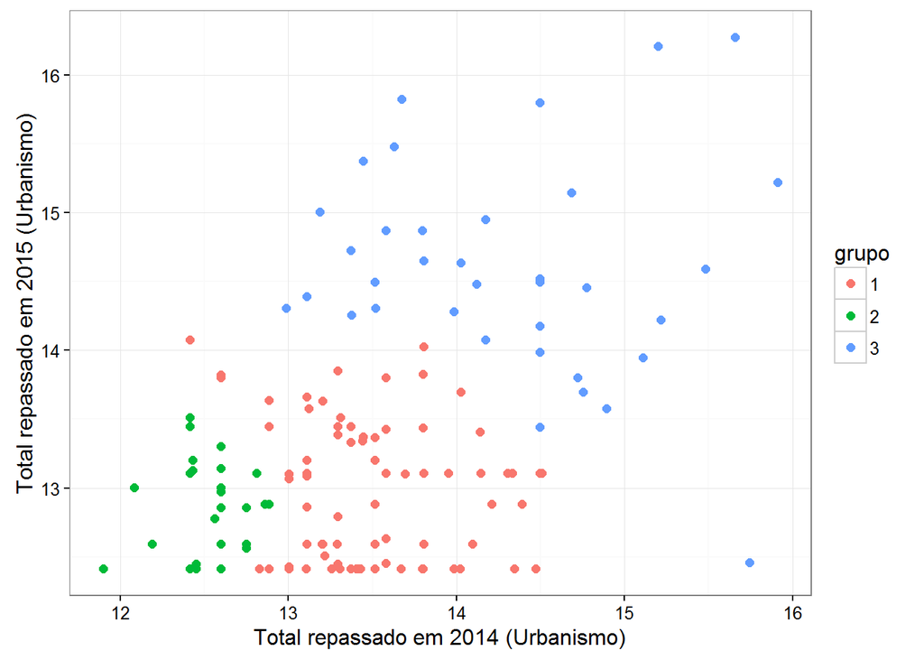

```
##            MUNIC_PROPONENTE UF_PROPONENTE
## 1                   ARACAJU            SE
## 2                 ARCOVERDE            PE
## 3                 BARREIRAS            BA
## 4                  BEBERIBE            CE
## 5                   CAMOCIM            CE
## 6            CAMPINA GRANDE            PB
## 7                  CANDEIAS            BA
## 8                   CARUARU            PE
## 9                CHAPADINHA            MA
## 10                   COREAU            CE
## 11                EUNAPOLIS            BA
## 12                FORQUILHA            CE
## 13                FORTALEZA            CE
## 14               FREI PAULO            SE
```

[output cut: 22 more lines]

Tentando fazer um agrupamento em 4 grupos, temos que o grupo intermediário que tínhamos anteriormente foi dividido em 2. Um que recebeu mais repasses em 2014 e outro que recebeu mais em 2015. Os outros dois permaneceram intactos.

Os últimos dois gráficos mostram a distribuição dos pontos nos grupos formados. Percebe-se que com quatro variáveis as cidades ficaram melhor distribuídas.

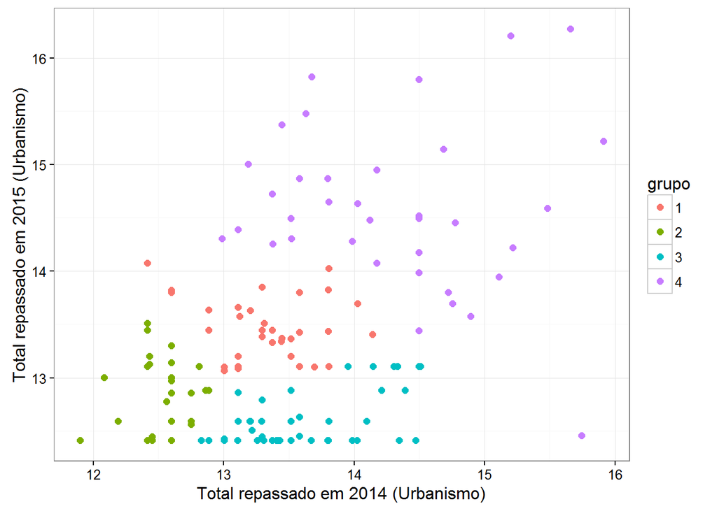

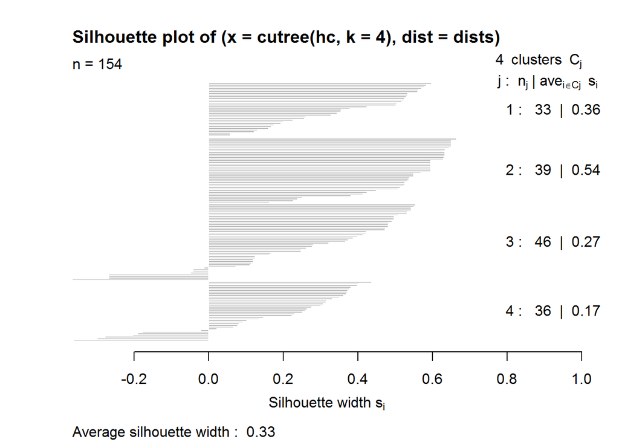

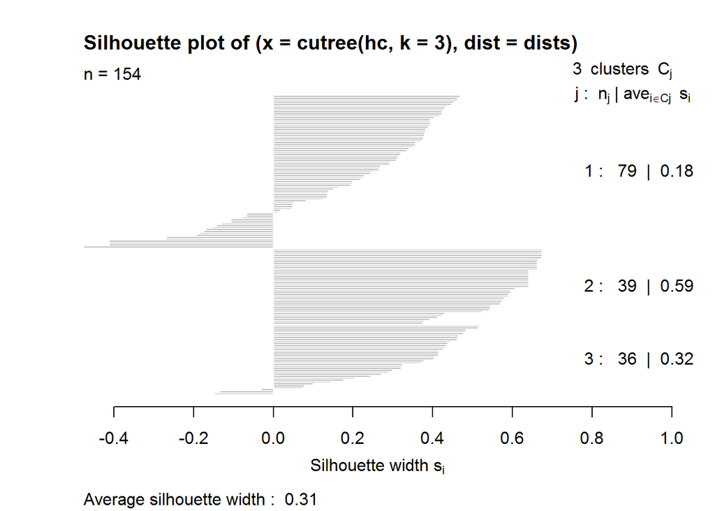